# PHRM4012: Introductory Lecture

Adam La Caze

# Overview

## Plan

1. Course aims and objectives
2. Contact and teaching staff
3. Assessment
4. Learning activities
5. Tips for success
6. Final Lecture
7. Questions?

## Course aim

PHRM4012 is a capstone course aimed at preparing you for practice:

> To optimise medicines use in patients through integration and application of pharmacy knowledge and skills in a range of over-the-counter and prescription medicine scenarios that reflect contemporary and future pharmacy practice.

## Learning objectives

1. Apply knowledge of medicines gained throughout the program to improve health outcomes (this includes medicines listed in the Personal Medicines Formulary)
2. Use effective communication skills to conduct successful consultations and provide patient-centred care in a range of simulated pharmacy practice scenarios
3. Identify and evaluate drug related problems in complex patient case scenarios
4. Develop and justify management plans to resolve drug related problems in complex patient case scenarios by appealing to clinical evidence and the patient’s context and goals
5. Contribute to team-based care with other members of the healthcare team in complex patient case scenarios
6. Discuss and apply a model of ethical decision making to complex patient case scenarios

## Contact

Adam La Caze

1. Post general course questions to the main Discussion Board
2. E: a.lacaze@uq.edu.au
3. To make an appointment: calendly.com/a-lacaze

## Teaching staff

| Patient-centred integrated cases | Simulation | Skills modules |
| --- | --- | --- |
| Kylie Mueller | Emma Baillie | Amelia Cossart |
| Matt Gibbs | Will Olsen | Adam La Caze |
| Emma Megram |  |  |

# Assessment

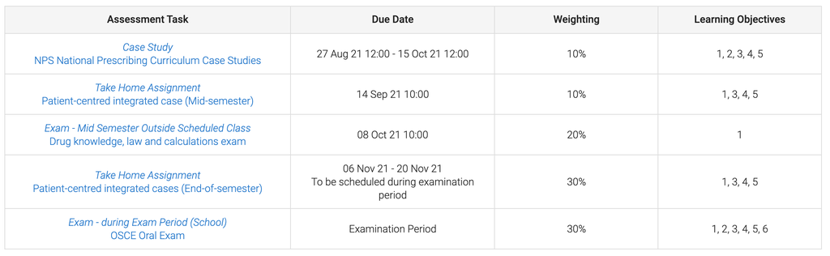

## NPS National Prescribing Curriculum Case Studies

- Create a [NPS MedicineWise account](https://learn.nps.org.au/auth/janrain/login/signup.php?)
- Complete 5 cases within the NPS National Prescribing Curriculum.
- Demonstrate that you have completed the case by uploading the completion certificate to Blackboard.
- You will receive 2% of the grade for each different case that you complete (10% total).

The certificate that you have completed the case needs to be uploaded by **midday Friday** in the following weeks:

- Week 5: Friday 27 August
- Week 6: Friday 3 September
- Week 7: Friday 10 September
- Week 9: Friday 24 September
- Week 11: Friday 15 October

## Patient-centred integrated cases (Take-home assignment)

- Provide a structured response to an integrated case.
- You will need to identify and prioritize any drug-related problems for the patient and provide a plan with appropriate monitoring for resolving the drug-related problem.
- Communicate your pharmaceutical care plan to appropriate members of the healthcare team
- Submit via Turnitin

Mid-semester (14 September)

- 3 hours to complete 1 case
- Completed during tutorial time
- 10% of grade

End-of-semester (examination period)

- 5 hours to complete 2 cases
- 30% of grade

## Drug knowledge, law and calculation exam

- Mid-semester (8 October)
- 60 minutes, 60 marks
- You need 60% of the marks to pass the assessment
- Drug knowledge: Personal Medicines Formulary (2020)
- Law: Key legal requirements that pharmacists need to know (HDPR, SUSMP, Privacy Act)
- Calculation: Be able to complete common pharmaceutical calculations

## Oral Structured Clinical Exam (Oral Exam)

The OSCE will consist in 4 stations.

- Over-the-counter consultation, symptom based (5 min)
- Over-the-counter consultation, product based (5 min)
- Prescription consultation (5 min)
- Ethics and law case (5 min)

You must pass 3/4 cases to pass the course.

OSCE is worth 30% of the course.

# Learning activities

## Patient-centred integrated cases

Tuesday 3 hour tutorials

Develop a **pharmaceutical care plan** for patients with multiple medical conditions and complex medication regimens.

We will use a simulated electronic medical record to deliver the cases. (Watch the introductory video in the folder).

## Preparation for patient-centred integrated cases

- Have a look at the content areas for each case
- Review relevant sections of e-TG, Uptodate and AMH
- Undertake the preparation quiz (from case 2)

## Practice Simulation/Consultation Skills

Friday 2 hour tutorial

Respond to common over-the-counter case scenarios

Roleplay as pharmacist/consumer

## Preparation for practice simulation

1. Review the relevant section of the *Consultation Skills* notes. Refer to additional resources such as the AMH, APF and MIMS Online to ensure you are able to manage the conditions that will be discussed.
2. Case scenarios will be released every Friday morning. These will be used for the role plays — don’t refer to these unless you are role playing the consumer/patient seeking help.
3. Take up the opportunity to role play the pharmacist as much as possible.

## Skills modules: Ethics

- Practice your model of ethical decision-making with a complex case
- Prepare for the OSCE Ethics and Law scenario (and practice and your intern exam)
- **Preparation** needed before the tutorial: review the ethics decision-making model and review the privacy law

## Skills modules: Communication

- Communication I: Patient consultations.

  Review and practice your approach to communication during patient consultations
- Communication II: ISBAR & PACE

  Practice structured communication with other members of the health team (ISBAR)

  Practice graded assertiveness: meeting your communication goals while avoiding and managing different in opinion and priorities

# Tips for success

## Tips for success

- Understand the goals of the course: the learning activities and assessment are focused on your transition to practice
- Are you safe? Are you well-equipped to help consumers achieve positive medication-related outcomes?
- Prepare for tutorials and engage (in person/online, via discussion board)—ask and answer questions
- Give and receive feedback

## Final lecture

**Friday 29 October** 10am–midday @PACE and online

- Celebrate your final lecture
- Great Debate
- Let’s talk about details